# Precept 3

Student von Student III

In this handout, we will learn how to create box plots, as well as how to calculate statistics for subsets of the data. These methods will allow for some simple ways to convey information about complex data.

- Creating box-and-whisker plots
- Placing multiple plots on one figure
- Creating tables
- Conditional statements
- Calculating means by subgroups
- Subsetting data
- Creating box-and-whisker plots through `boxplot`
- Calculating a statistic by groups of data using `tapply`
- Creating variables through using the conditional statement `ifelse`
- Placing multiple plots in one figure by setting `mfrow` with the `par` function

**Before beginning this handout, do not forget to make a new folder for this assignment and set your working directory!**

# Introduction to Data

First, we read in the data:

```r
PeaceData <- read.table("data/PeaceData.txt", header = TRUE)
head(PeaceData)
```

```
                cname UN     ldur lwdeaths lwdurat   ethfrac       pop
1               Haiti  0 2.397895 0.000000       9  1.359123  8.775395
2               Haiti  1 4.962845 5.521461      12  1.359123  8.813141
3 Trinidad and Tobago  0 5.068904 3.401197       1 55.843151  7.102499
4              Mexico  0 3.401197 4.976734       1 30.510818 11.401994
5              Mexico  0 4.418840 0.000000       4 30.510818 11.449986
6           Guatemala  1 4.553877 5.703783      12 64.368416  9.230143
  continent
1  lamerica
2  lamerica
3  lamerica
4  lamerica
5  lamerica
6  lamerica
```

```r
summary(PeaceData)
```

```
        cname          UN              ldur           lwdeaths
 Iran      : 5   Min.   :0.0000   Min.   :0.6931   Min.   : 0.000
 Senegal   : 4   1st Qu.:0.0000   1st Qu.:2.3979   1st Qu.: 5.187
 Chad      : 3   Median :0.0000   Median :3.8501   Median : 6.812
 Indonesia : 3   Mean   :0.2184   Mean   :3.5509   Mean   : 7.157
 Niger     : 3   3rd Qu.:0.0000   3rd Qu.:4.5539   3rd Qu.: 9.926
 Azerbaijan: 2   Max.   :1.0000   Max.   :5.1874   Max.   :13.229
 (Other)   :67
    lwdurat          ethfrac             pop            continent
 Min.   :  1.00   Min.   : 0.4975   Min.   : 6.363   asia    :13
 1st Qu.:  9.50   1st Qu.:33.4221   1st Qu.: 8.398   eeurop  :17
 Median : 23.00   Median :65.4930   Median : 9.004   lamerica:12
 Mean   : 56.89   Mean   :54.9115   Mean   : 9.344   nafrme  :10
 3rd Qu.: 60.00   3rd Qu.:75.1710   3rd Qu.:10.201   ssafrica:35
 Max.   :360.00   Max.   :90.1632   Max.   :12.139
```

The data contains the following variables:

[output not shown]

# Calculating Statistics for Subsets of the Data

First, we are going to calculate the mean duration until the next conflict, by continent. To do so, we are going to use the command `tapply`. This function takes three arguments

- `X`. A variable to which we want to apply a function
- `INDEX`. A variable defining the groups within which we want to apply the function
- `FUN`. The function we want to apply

For example, if we wanted to calculate the mean duration to conflict by continent, we could

```r
tapply(PeaceData$ldur, INDEX = PeaceData$continent, FUN = mean)
```

```
    asia   eeurop lamerica   nafrme ssafrica
3.228947 3.585509 4.493616 3.582937 3.321299
```

```r
# Mean for countries w UN intervention
inter1 <- tapply(PeaceData$ldur[PeaceData$UN == 1],
                 INDEX = PeaceData$continent[PeaceData$UN == 1],
                 FUN = mean)
inter1
```

```
    asia   eeurop lamerica   nafrme ssafrica
      NA 3.818642 4.899390 5.080709 3.987808
```

```r
# Mean for countries without a UN intervention
inter0 <- tapply(PeaceData$ldur[PeaceData$UN == 0],
                 INDEX = PeaceData$continent[PeaceData$UN == 0],
                 FUN = mean)
inter0
```

```
    asia   eeurop lamerica   nafrme ssafrica
3.228947 3.422315 4.290729 3.208494 3.183400
```

```r
inter1 - inter0
```

```
     asia    eeurop  lamerica    nafrme  ssafrica
       NA 0.3963275 0.6086607 1.8722157 0.8044079
```

It appears that the UN did not intervene in any Asian country (as shown by the `NA under Asia in the first row. Also, it appears that UN intervention is associated with an increase in duration to the next conflict, since the differences are all positive The difference appears largest in the North Africa / Middle East`nafrm`.

We can put any function into `tapply` that we like: `sd`, `median`, and so on.  
`tapply` can also be used to calculate the number of observations in each category, by setting `FUN = length`. For example

```r
tapply(PeaceData$ldur,
       INDEX = PeaceData$continent,
       FUN = length)
```

```
    asia   eeurop lamerica   nafrme ssafrica
      13       17       12       10       35
```

# Conditional Statements

We may also want to create conditional statements. We do this through the command `ifelse`. The command takes three arguments:

- `test`. A logical expression (one that is either true or false) e.g. `x < 2` or `x == "asia"`.
- `yes`. What to return if the `test` is TRUE
- `no`. What to return if the `test is FALSE

For example, let’s say we wanted to create a variable that took on a value of 1 for observations with high values of ethno-linguistic fractionalization, and a 0 for observations with low values of ethno-linguistic fractionalization. We could do so using

```r
high.ethfrac <- ifelse(PeaceData$ethfrac > median(PeaceData$ethfrac), 1, 0)
```

We have just created a variable, `high.ethfrac`, which takes on a value of 1 when `ethfrac` is above its median, and 0 when `ethfrac` is below its median. If we look at this new variable

```r
table(high.ethfrac)
```

```
high.ethfrac
 0  1
44 43
```

we can see that we do have, approximately, half 1’s and half 0’s.

# Creating Box-and-Whisker Plots

R makes creating box-and-whisker plots straightforward. The command is `boxplot`, and if we place a variable in the function, it returns a box plot, as:

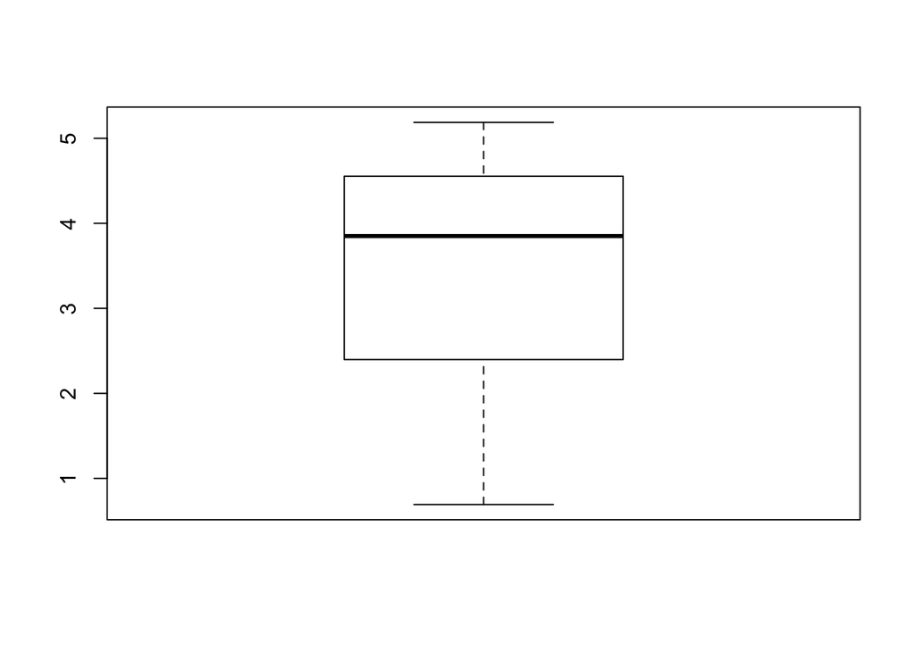

```r
boxplot(PeaceData$ldur)
```

The function `boxplot` can be used to construct separate boxes for the categories of a different variable. For example, let’s say we wanted to look at the box plots for countries that did and did not experience a UN intervention:

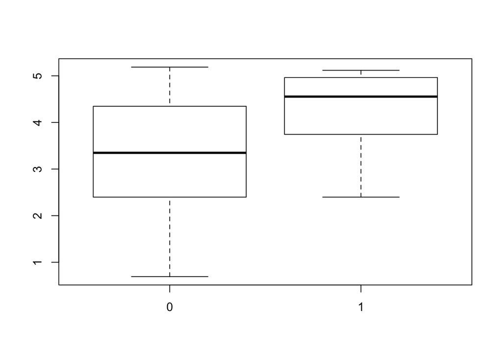

```r
boxplot(PeaceData$ldur ~ PeaceData$UN)
```

It appears, from this simple box plot, that the UN interventions are associated with longer periods of peace. Just like with the density plots from the previous handout, we can give the box plot a title and y-axis label, by setting the `main` and and `ylab` parameters to suitable values:

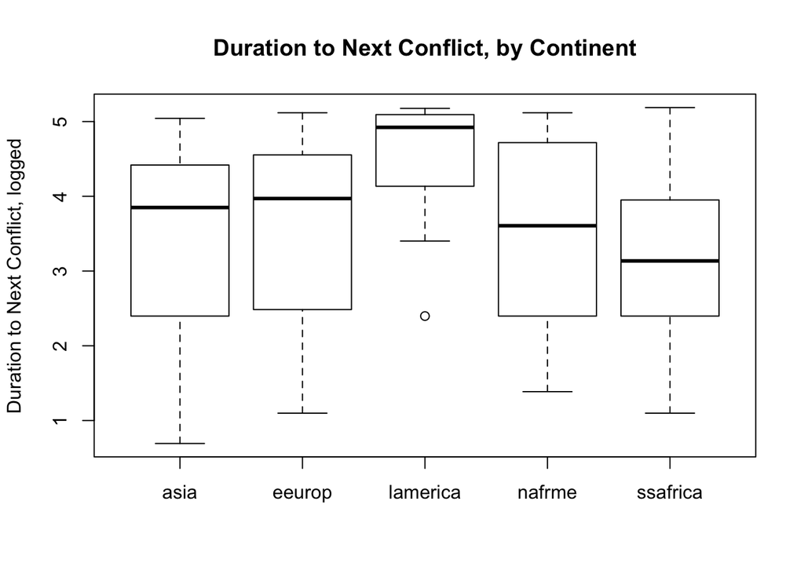

```r
boxplot(PeaceData$ldur ~ PeaceData$continent,
        main = "Duration to Next Conflict, by Continent",
        ylab = "Duration to Next Conflict, logged" )
```

# Placing Several Plots in One Figure

Finally, we are going to add a command that allows for multiple plots in one figure. To do so, we need adjust R’s default plot parameters. We’ll use the `par` function to set the value of `mfrow` which controls how plots are arranged in the plotting window. We use `par` to set `mfrow` like this:

> par(mfrow = c(*number of rows*, *number of columns*))

and we have to remember to put this line *before* (that is, above) any plots we make.

When mfrow is set this way each new plot we make will start in a new part of the figure. To give an example, let’s say we wanted to create three box plots in a row, where the first contains a box plot of duration by intervention, the next contains the same box plot for countries with a high level of ethno-linguistic fractionalization (`high.ethfrac == 1`), and the final contains the same box plot but only when ethno-linguistic fractionalization is low (`high.ethfrac == 0`).

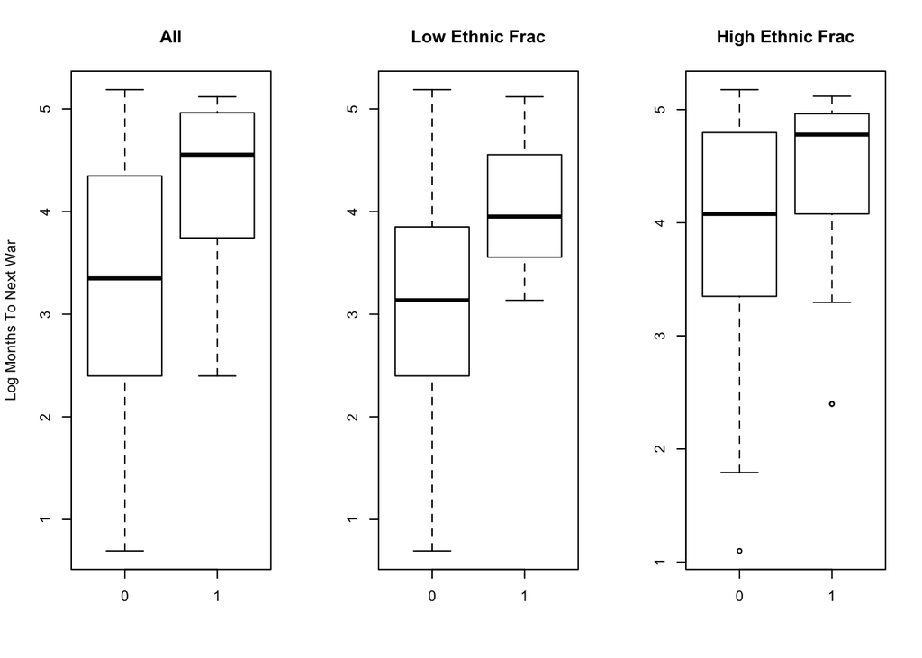

```r
par(mfrow = c(1, 3)) # One row, three columns

boxplot(PeaceData$ldur ~ PeaceData$UN,
        main = "All", ylab = "Log Months To Next War")
boxplot(PeaceData$ldur[high.ethfrac == 1] ~ PeaceData$UN[high.ethfrac == 1],
        main = "Low Ethnic Frac") # High ethfrac countries
boxplot(PeaceData$ldur[high.ethfrac == 0] ~ PeaceData$UN[high.ethfrac == 0],
        main = "High Ethnic Frac") # Low ethfrac countries
```

# Precept Problems

In these problems, we analyze the relationship between disaster relief aid and support for the incumbent President’s party, from 1988-2004. Political economists have long theorized that incumbent political leaders may “buy” votes, through dispensing aid to sub-national political units in order to shore up electoral support.

Healy and Malhotra (2009) examined whether this effect is present in the contemporary United States. We are going to conduct an abridged version of their study, though the basic findings will be similar. The authors explored the relationship between county-level support for the incumbent President’s party and disaster aid disbursed to the county. Each observation is a county in the United States, observed in the four years before five consecutive elections (1988, 1992, 1996, 2000, and 2004).

We are going to use a subset of the authors’ original dataset. Like the authors, we are interested in characterizing a causal relationship between disaster aid disbursement and support for the incumbent party’s candidate in the election.

The dataset {disasteraid.csv} is available as a csv file at Blackboard and contains the following variables:

| Name | Description |
| --- | --- |
| `fips` | An identifier for each county. This is the level of government that received aid |
| `year` | The year of the variables are observed |
| `incum_vote` | The percentage of the vote received by the incumbent’s party for that county in that election |
| `prev_incum` | The percentage of the vote received by the incumbent’s party in the previous election |
| `all_current_irelief` | A measure of disaster aid relief received, per capita, in the county. |

We first create a variable, `relief`, that is the treatment variable.  
Create this variable such that it is 1 if `all_current_irelief` is greater than 0, and it is 0 if it is less or equal to 0.

Next, to measure the difference in support for the incumbent’s party, create a variable `diff.vote`, that is equal to the incumbent party candidate’s current vote minus their previous vote.

Calculate the difference in means between `diff.vote` for those observations for which `relief == 0` and `diff.vote` for those observations for which `relief == 1`.

What is this difference in these two means?

Does this difference seem substantively important? (Hint: The difference between Romney and Obama in the 2012 popular vote was 3.9 percent.)

What does this difference imply for the ability of Presidents to buy votes (if it is interpreted as causal)?

Now generate a table with two rows. The first row should have the mean of `relief` by year and the second should have `diff.vote` by year.  
(You can make the table by just copying directly from the console.)

Looking at the mean of `diff.vote`, one of the years clearly stands out as an outlier. What occurred in this election that may have affected `diff.vote`? (Hint: Use Google or Wikipedia.)

Looking at the mean of `relief`, one of the years clearly stands out as an outlier. What occurred between 2000 and 2004 that may have affected this variable? Explain the nature and type of bias, and how this event may be biasing the causal effect estimate of `relief` and `diff.vote`.

Create a box plot of `all_current_irelief` by year. Next, construct a box plot `diff.vote` by year.

Was there an event between 2000 and 2004 that affected both disaster relief expenditures *and* support for President Bush? How does this event cast doubt on the causal claim the authors are attempting to make?

# Example: Multiple Density Plots in One Figure

To provide you with an additional example, we are going to create a figure of density plots. The density plot will

- Be sized 3 x 2. The upper left corner (the first plot) should use the raw data.  
  The remaining plots should use data from 1988, 1992, 1996, 2000, and 2004, respectively
- Each of the six figures should contain two density plots. The first (in black) is the density of `diff.vote` for the observations for which `relief == 1`. The second (in red) should be in the same figure, with the density of `diff.vote` for the observations for which `relief == 0`
- The x-axes and y-axes should be the *same across all plots*
- Each plot should have informative axis labels and titles
- The top two figures should have a legend. If necessary, you should lengthen the y-axis so that the legend does not overlap with the density plot.

The code for this practice problem is below. You do not have to hand anything in here; working through this code will help you with the upcoming problem set. Even though the code looks long, please notice that it is basically the same bit of code copied six times. In each instance after the first, the year is changed, but the rest remains the same. Please feel free to copy code from one part of your work to the next; there is no reason to retype the code over and over.

```r
par(mfrow = c(3, 2))

## Top left figure -- All data
plot(density(diff.vote[(relief == 1)]),
     xlim = c(-30, 20), ylim = c(0, 0.14),
     main = "All", xlab = "Change in Vote Percentage")
lines(density(diff.vote[(relief == 0)]), col = "red")
legend("topleft", c("Relief",  "No Relief"),
       lty = c(1, 1), col = c("black", "red"))

## 1988 data
plot(density(diff.vote[(relief == 1) & (disasteraid$year == 1988)]),
     xlim = c(-30, 20), ylim = c(0, 0.14), main = "1988",
     xlab = "Change in Vote Percentage")
lines(density(diff.vote[(relief == 0) & disasteraid$year == 1988)]),
      col = "red")
legend("topright", c("Relief",  "No Relief"),
       lty = c(1, 1), col = c("black", "red"))

## 1992 data
plot(density(diff.vote[(relief == 1) & (disasteraid$year == 1992)]),
     xlim = c(-30, 20), ylim = c(0, 0.14),
     main = "1992", xlab = "Change in Vote Percentage")
lines(density(diff.vote[(relief == 0) & disasteraid$year == 1992)]),
      col = "red")

## 1996 data
plot(density(diff.vote[(relief == 1) & (disasteraid$year == 1996)]),
     xlim = c(-30, 20), ylim = c(0, 0.14),
     main = "1996", xlab = "Change in Vote Percentage")
lines(density(diff.vote[(relief == 0) & (disasteraid$year == 1996)]),
      col = "red")

## 2000 data
plot(density(diff.vote[(relief == 1) & (disasteraid$year == 2000)]),
     xlim = c(-30, 20), ylim = c(0, 0.14),
     main = "2000", xlab = "Change in Vote Percentage")
lines(density(diff.vote[(relief == 0) & (disasteraid$year == 2000)]),
      col = "red")

## 2004 data
plot(density(diff.vote[(relief == 1) & (disasteraid$year == 2004)]),
     xlim = c(-30, 20), ylim = c(0, 0.14),
     main = "2004", xlab = "Change in Vote Percentage")
lines(density(diff.vote[(relief == 0) & (disasteraid$year == 2004)]),
      col = "red")

 # reset mfrow so future plots don't appear in this configuration!
par(mfrow = c(1, 1))
```

Gilligan, Michael J., and Ernest J. Sergenti. 2008. “Do UN Interventions Cause Peace? Using Matching to Improve Causal Inference.” *Quarterly Journal of Political Science* 3 (2): 89–122. doi:10.1561/100.00007051.

Healy, Andrew, and Neil Malhotra. 2009. “Myopic Voters and Natural Disaster Policy.” *American Political Science Review* 103 (03): 387–406. doi:10.1017/S0003055409990104.